# HiFi Full-length 16S Analysis Report

## Summary QC statistics

- Samples number: 1
- Final samples number post-DADA2: 1
- Missing samples (Not enough reads, do not pass QC, etc):
- Total number of CCS reads before filtering and primers trimming: 78328
- Was primers trimmed prior to DADA2? Yes
- Note that if downsampling was enabled, the reads will be filtered first, then restricted to a maximum of N reads.
- Total number of reads after quality filtering: 78328 (100%)
- Total number of reads after primers trimming (DADA2 input): 77628 (99.11%)
- Total number of ASVs found: 51
- Average number of ASVs per sample: 51
- Total number of reads in 51 ASVs: 77538 (99.88% of all input reads)

### Classification using VSEARCH with a single database

- ASVs classified at Species level: 50 (98.04%)
- ASVs classified at Species level (Excluding metagenome/uncultured entries): 50 (98.04%)
- Percentage reads belong to ASV classified at Species level (Excluding metagenome/uncultured entries): 100%
- ASVs classified at Genus level: 51 (100%)
- ASVs classified at Genus level (Excluding metagenome/uncultured entries): 51 (100%)
- Percentage reads belong to ASV classified at Genus level (Excluding metagenome/uncultured entries): 100%

### Classification using Naive Bayes classifier with SILVA, GTDB and RefSeq + RDP

- ASVs classified at Species level: 48 (94.12%)
- ASVs classified at Species level (Excluding metagenome/uncultured entries): 48 (94.12%)
- Percentage reads belong to ASV classified at Species level (Excluding metagenome/uncultured entries): 92%
- ASVs classified at Genus level: 50 (98.04%)
- ASVs classified at Genus level (Excluding metagenome/uncultured entries): 50 (98.04%)
- Percentage reads belong to ASV classified at Genus level (Excluding metagenome/uncultured entries): 98%

## Overall reads filtering and number of full-length reads

- Full-length reads are defined as reads with both F27 and R1492 primers
- Note that full length counts column will only show if cutadapt was used to trim primers (default).

|  | Sample | Reads before quality filter | Reads after quality filter | Full-length Reads | Full-length Reads Percent |
| --- | --- | --- | --- | --- | --- |
| 1 | BEI_FL16S | 78328 | 78328 | 77628 | 0.991063221325707 |

## Input reads QC (Before filtering and primers removal)

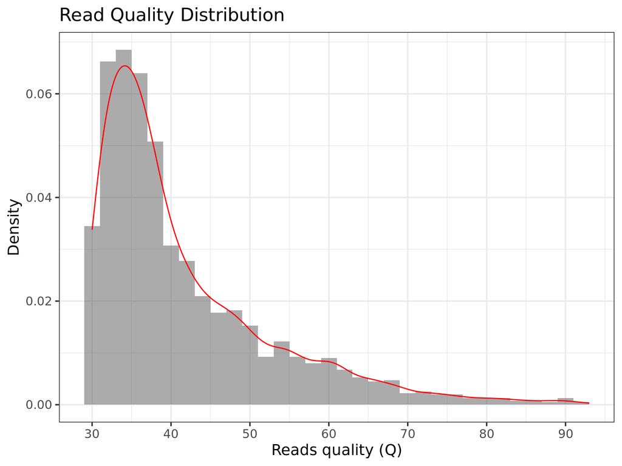

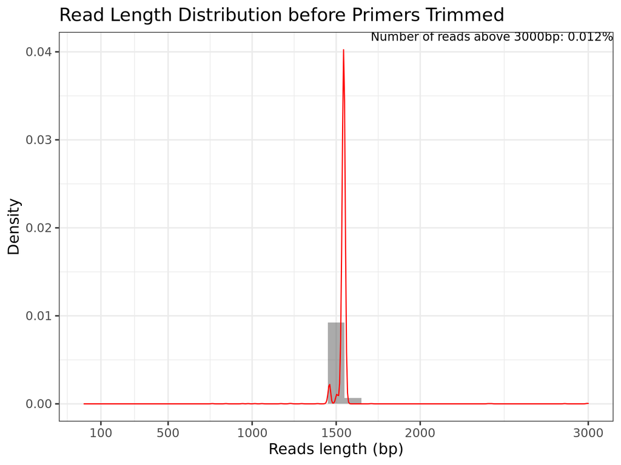

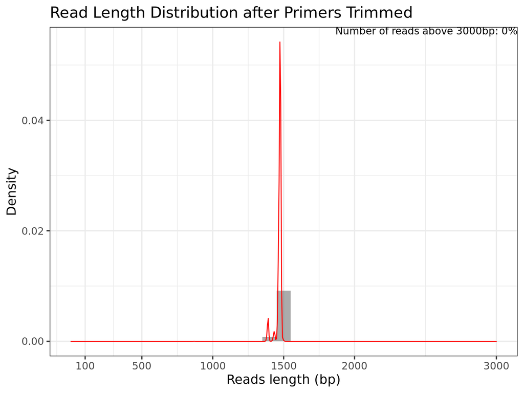

|  | Sample | Median Length (bp) | Median Read Quality | Length 1st Quartile (bp) | Length 3rd Quartile (bp) | Read Quality 1st Quartile (bp) | Read Quality 3rd Quartile (bp) |
| --- | --- | --- | --- | --- | --- | --- | --- |
| 1 | BEI_FL16S | 1544 | 37.81 | 1536 | 1549 | 33.78 | 46.59 |

## DADA2 QC metrics

|  | sample-id | input | filtered | percentage of input passed filter | denoised | non-chimeric | percentage of input non-chimeric | n_ASV |
| --- | --- | --- | --- | --- | --- | --- | --- | --- |
| 1 | BEI_FL16S | 77628 | 77597 | 99.96 | 77538 | 77538 | 99.88 | 51 |

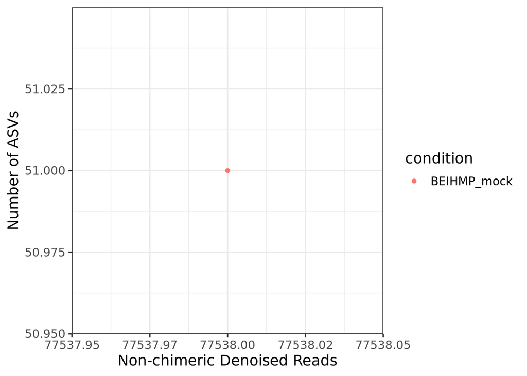

## Top Taxa and Plots

- For interactive view, use the Emperor QZV output from QIIME2 in `results/core-metrics-diversity` folder with QIIME2 View
- Note that if the distances between all samples are zero for a specific method, the plots will not be shown.
- MDS plots use ASVs as input.
- Samples might be missing due to choice of rarefecation depth. Rerun pipeline with `-resume --rarefaction_depth X` to choose a custom rarefaction depth X.

### Bray-Curtis MDS plot

```
## [1] "Bray-Curtis matrix is empty (Did you process only one sample?)"
```

### Weighted and Unweighted Unifrac MDS plot

```
## [1] "Weighted unifrac matrix is empty (Did you process only one sample?)"
```

```
## [1] "Unweighted unifrac matrix is empty (Did you process only one sample?)"
```

### Top 50 ASVs (VSEARCH classification)

|  | OTU | Kingdom | Phylum | Class | Order | Family | Genus | Species | BEI_FL16S |
| --- | --- | --- | --- | --- | --- | --- | --- | --- | --- |
| 1 | a0530711bdec8d611872863731f96dde | Bacteria | Firmicutes | Bacilli | Lactobacillales | Streptococcaceae | Streptococcus | Streptococcus mutans | 16207 |
| 2 | f3cfb383dcfb753cad226072f6665784 | Bacteria | Firmicutes | Bacilli | Staphylococcales | Staphylococcaceae | Staphylococcus | Staphylococcus epidermidis | 9292 |
| 3 | bc7d5e82dae59e2e5e8321bb5c5eae4b | Bacteria | Firmicutes | Bacilli | Lactobacillales | Streptococcaceae | Streptococcus | Streptococcus mutans | 7390 |
| 4 | dd586a1ae04ed2d129d944286ae71f61 | Bacteria | Firmicutes | Bacilli | Staphylococcales | Staphylococcaceae | Staphylococcus | Staphylococcus epidermidis | 4697 |
| 5 | b80a1bd6b19379171cafb03a4ddb26a3 | Bacteria | Proteobacteria | Alphaproteobacteria | Rhodobacterales | Rhodobacteraceae | Cereibacter A | Cereibacter A sphaeroides | 4098 |
| 6 | aab4d379026eb5e6a7e2b32ec4c715e7 | Bacteria | Firmicutes | Bacilli | Staphylococcales | Staphylococcaceae | Staphylococcus | Staphylococcus epidermidis | 4060 |
| 7 | d3eab112b21cbea371f808f940fa4b0c | Bacteria | Firmicutes | Bacilli | Staphylococcales | Staphylococcaceae | Staphylococcus | Staphylococcus epidermidis | 4027 |
| 8 | 34babcf1732962962d2fbbbadf3af637 | Bacteria | Firmicutes | Bacilli | Staphylococcales | Staphylococcaceae | Staphylococcus | Staphylococcus epidermidis | 3804 |
| 9 | 13bc41e35faa4f40a01de5a972c0c4ac | Bacteria | Proteobacteria | Gammaproteobacteria | Enterobacterales | Enterobacteriaceae | Escherichia | Escherichia coli | 3625 |
| 10 | 07b2978940b50886f3866b04b7f982cf | Bacteria | Firmicutes | Bacilli | Lactobacillales | Streptococcaceae | Streptococcus | Streptococcus agalactiae | 3215 |

[output cut: 40 more lines]

### Top 10 Classified Genus (Collapsed to species) with VSEARCH

- Relative abundance is calculated by dividing the number of reads for each ASV to the total number of reads in each sample.
- Heatmap contains only species with >1% abundance in at least 2 samples for the top 10 genus.

|  | Genus | Mean supporting reads across samples | Mean relative abundance across samples |
| --- | --- | --- | --- |
| 1 | Staphylococcus | 27739 | 0.36 |
| 2 | Streptococcus | 26812 | 0.35 |
| 3 | Escherichia | 13362 | 0.17 |
| 4 | Cereibacter A | 4098 | 0.05 |
| 5 | Bacillus A | 2380 | 0.03 |
| 6 | Clostridium | 1697 | 0.02 |
| 7 | Acinetobacter | 137 | 0 |
| 8 | Cutibacterium | 67 | 0 |
| 9 | Enterococcus | 19 | 0 |
| 10 | Helicobacter | 321 | 0 |

[output cut: 5 more lines]

|  | Genus | Species | BEI_FL16S |
| --- | --- | --- | --- |
| 1 | Staphylococcus | Staphylococcus aureus | 1859 |
| 2 | Staphylococcus | Staphylococcus epidermidis | 25880 |
| 3 | Streptococcus | Streptococcus agalactiae | 3215 |
| 4 | Streptococcus | Streptococcus mutans | 23597 |
| 5 | Escherichia | Escherichia coli | 13362 |
| 6 | Cereibacter A | Cereibacter A sphaeroides | 4098 |
| 7 | Bacillus A | Bacillus A paranthracis | 2380 |
| 8 | Clostridium | Clostridium beijerinckii | 1697 |
| 9 | Acinetobacter | Acinetobacter baumannii | 137 |
| 10 | Cutibacterium | Cutibacterium acnes | 67 |

[output cut: 8 more lines]

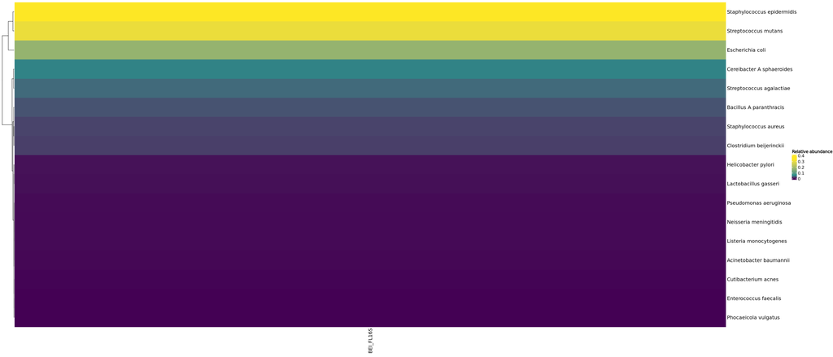

### Top 50 ASVs (Naive Bayes Classifier)

|  | OTU | Kingdom | Phylum | Class | Order | Family | Genus | Species | BEI_FL16S |
| --- | --- | --- | --- | --- | --- | --- | --- | --- | --- |
| 1 | a0530711bdec8d611872863731f96dde | Bacteria | Firmicutes | Bacilli | Lactobacillales | Streptococcaceae | Streptococcus | Streptococcus mutans | 16207 |
| 2 | f3cfb383dcfb753cad226072f6665784 | Bacteria | Firmicutes | Bacilli | Staphylococcales | Staphylococcaceae | Staphylococcus | Staphylococcus epidermidis | 9292 |
| 3 | bc7d5e82dae59e2e5e8321bb5c5eae4b | Bacteria | Firmicutes | Bacilli | Lactobacillales | Streptococcaceae | Streptococcus | Streptococcus mutans | 7390 |
| 4 | dd586a1ae04ed2d129d944286ae71f61 | Bacteria | Firmicutes | Bacilli | Staphylococcales | Staphylococcaceae | Staphylococcus | Staphylococcus epidermidis | 4697 |
| 5 | b80a1bd6b19379171cafb03a4ddb26a3 | Bacteria | Proteobacteria | Alphaproteobacteria | Rhodobacterales | Rhodobacteraceae | Cereibacter A | Cereibacter A sphaeroides | 4098 |
| 6 | aab4d379026eb5e6a7e2b32ec4c715e7 | Bacteria | Firmicutes | Bacilli | Staphylococcales | Staphylococcaceae | Staphylococcus | Staphylococcus epidermidis | 4060 |
| 7 | d3eab112b21cbea371f808f940fa4b0c | Bacteria | Firmicutes | Bacilli | Staphylococcales | Staphylococcaceae | Staphylococcus | Staphylococcus epidermidis | 4027 |
| 8 | 34babcf1732962962d2fbbbadf3af637 | Bacteria | Firmicutes | Bacilli | Staphylococcales | Staphylococcaceae | Staphylococcus | Staphylococcus epidermidis | 3804 |
| 9 | 13bc41e35faa4f40a01de5a972c0c4ac | Bacteria | Proteobacteria | Gammaproteobacteria | Enterobacterales | Enterobacteriaceae | Escherichia-Shigella | Escherichia-Shigella coli | 3625 |
| 10 | 07b2978940b50886f3866b04b7f982cf | Bacteria | Firmicutes | Bacilli | Lactobacillales | Streptococcaceae | Streptococcus | Streptococcus agalactiae | 3215 |

[output cut: 40 more lines]

### Top 10 Classified Genus (Collapsed to species) with Naive Bayes Classifier

- Relative abundance is calculated by dividing the number of reads for each ASV to the total number of reads in each sample.
- Heatmap contains only species with >1% abundance in at least 2 samples for the top 10 genus.

|  | Genus | Mean supporting reads across samples | Mean relative abundance across samples |
| --- | --- | --- | --- |
| 1 | Staphylococcus | 27739 | 0.36 |
| 2 | Streptococcus | 26812 | 0.35 |
| 3 | Escherichia-Shigella | 5321 | 0.07 |
| 4 | Cereibacter A | 4098 | 0.05 |
| 5 | Escherichia | 4191 | 0.05 |
| 6 | Bacillus | 2380 | 0.03 |
| 7 | Clostridium | 1573 | 0.02 |
| 8 | Collinsella | 1930 | 0.02 |
| 9 | Acinetobacter | 137 | 0 |
| 10 | Clostridium sensu stricto 1 | 124 | 0 |

[output cut: 8 more lines]

|  | Genus | Species | BEI_FL16S |
| --- | --- | --- | --- |
| 1 | Staphylococcus | Staphylococcus aureus | 1859 |
| 2 | Staphylococcus | Staphylococcus epidermidis | 25880 |
| 3 | Streptococcus | Streptococcus agalactiae | 3215 |
| 4 | Streptococcus | Streptococcus mutans | 23597 |
| 5 | Escherichia-Shigella | Escherichia-Shigella coli | 5321 |
| 6 | Cereibacter A | Cereibacter A sphaeroides | 4098 |
| 7 | Escherichia | Unclassified | 4191 |
| 8 | Bacillus | Bacillus anthracis | 2229 |
| 9 | Bacillus | Bacillus cereus | 151 |
| 10 | Clostridium | Clostridium beijerinckii | 1573 |

[output cut: 13 more lines]

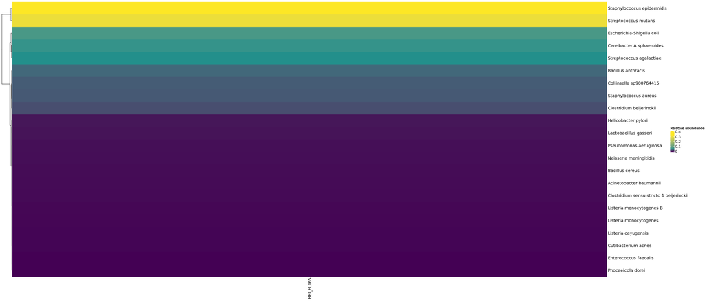